# Predicting Amazon Stock Price: A Time Series Analysis

Team 07

Load libraries

```r
library(forecast)
library(tidyverse)
library(zoo)
```

```r
library(corrplot)
library(ggplot2)
library(patchwork)
```

Load Data

```r
# Amazon
Amazon <- read.csv("amzn_split_adjusted.csv")

# S&P500
sp_data <- read.csv("SP_Historical_Data.csv")
```

Data Cleaning - Amazon

```r
# Display the first few rows of the 'Amazon' dataset
head(Amazon)
```

|  | date | open | high | low | close | volume | raw_close | change_percent | avg_vol_20d |
| --- | --- | --- | --- | --- | --- | --- | --- | --- | --- |
| 1 | 1997-05-15 | 0.12190 | 0.12500 | 0.09635 | 0.09790 | 1442159938 | 23.496 | NA | NA |
| 2 | 1997-05-16 | 0.09845 | 0.09895 | 0.08540 | 0.08645 | 293999987 | 20.748 | -11.64 | NA |
| 3 | 1997-05-19 | 0.08800 | 0.08855 | 0.08125 | 0.08540 | 122135995 | 20.496 | -1.27 | NA |
| 4 | 1997-05-20 | 0.08645 | 0.08750 | 0.08175 | 0.08175 | 109343995 | 19.620 | -4.22 | NA |
| 5 | 1997-05-21 | 0.08175 | 0.08230 | 0.06875 | 0.07135 | 377063984 | 17.124 | -12.71 | NA |
| 6 | 1997-05-22 | 0.07190 | 0.07240 | 0.06565 | 0.06980 | 235535990 | 16.752 | -2.24 | NA |

```r
# Creating a new dataset 'Amazon_clean' by removing rows with missing values
Amazon_clean <- na.omit(Amazon)

# Print the count of missing values in the 'Amazon_clean' dataset
sum(is.na(Amazon_clean))
```

```
## [1] 0
```

```r
# Display summary statistics of the 'Amazon_clean' dataset
summary(Amazon_clean)
```

```
##      date                open                high               low
##  Length:6646        Min.   :  0.07525   Min.   :  0.0758   Min.   :  0.07395
##  Class :character   1st Qu.:  2.04688   1st Qu.:  2.0870   1st Qu.:  2.00413
##  Mode  :character   Median :  7.12350   Median :  7.1780   Median :  6.98675
##                     Mean   : 33.81046   Mean   : 34.2184   Mean   : 33.36698
##                     3rd Qu.: 44.24375   3rd Qu.: 44.6352   3rd Qu.: 44.12650
##                     Max.   :187.20001   Max.   :188.6539   Max.   :184.83965
##      close              volume            raw_close       change_percent
##  Min.   :  0.0745   Min.   :5.352e+06   Min.   :   5.97   Min.   :-24.7700
##  1st Qu.:  2.0492   1st Qu.:6.748e+07   1st Qu.:  47.26   1st Qu.: -1.3175
##  Median :  7.1048   Median :1.043e+08   Median : 126.58   Median :  0.0500
##  Mean   : 33.8000   Mean   :1.404e+08   Mean   : 563.81   Mean   :  0.1758
##  3rd Qu.: 44.3036   3rd Qu.:1.590e+08   3rd Qu.: 547.50   3rd Qu.:  1.4800
##  Max.   :186.5705   Max.   :2.086e+09   Max.   :3731.41   Max.   : 34.4700
##   avg_vol_20d
##  Min.   : 25341599
##  1st Qu.: 75114608
##  Median :115057313
##  Mean   :140490251
##  3rd Qu.:166941030
##  Max.   :832882176
```

```r
# Create a new dataset 'amazon_filter' by filtering rows with dates greater than or equal to 2013-11-14
amazon_filter <- Amazon_clean %>%
  filter(date >= "2013-11-14")

head(amazon_filter)
```

|  | date | open | high | low | close | volume | raw_close | change_percent | avg_vol_20d |
| --- | --- | --- | --- | --- | --- | --- | --- | --- | --- |
| 1 | 2013-11-14 | 17.8695 | 18.4470 | 17.8215 | 18.3698 | 83282559 | 367.396 | 3.14 | 74009355 |
| 2 | 2013-11-15 | 18.3815 | 18.6450 | 18.2775 | 18.4585 | 89895459 | 369.170 | 0.48 | 72534314 |
| 3 | 2013-11-18 | 18.5140 | 18.6745 | 18.2335 | 18.3090 | 54764279 | 366.180 | -0.81 | 72744911 |
| 4 | 2013-11-19 | 18.2910 | 18.4390 | 18.1250 | 18.2470 | 38095939 | 364.940 | -0.34 | 70706755 |
| 5 | 2013-11-20 | 18.3780 | 18.3780 | 18.0225 | 18.1285 | 35459680 | 362.570 | -0.65 | 69661581 |
| 6 | 2013-11-21 | 18.2025 | 18.4625 | 18.1650 | 18.4460 | 39340819 | 368.920 | 1.75 | 65743967 |

Clean and Join amazon and S&P Data to test correlation

```r
# Convert the 'Date' column to a Date format in the 'sp_data' dataset
sp_data_new <- sp_data %>%
  mutate(date = as.Date(Date, format = "%m/%d/%Y"))

# Creating a new dataset 'sp_data_final' by removing the original 'Date' column
sp_data_final <- sp_data_new %>%
  select(-Date)

# Filtering the 'sp_data_final' dataset to include only rows with dates on or before "2023-11-7"
sp_filter <- sp_data_final %>%
  filter(date <= "2023-11-7")

# Convert the 'date' column to character format in the filtered dataset 'sp_filter'
sp_filter1 <- sp_filter %>%
  mutate(date = as.character(date))
sp_filter1
```

| Close.Last | Open | High | Low | date |
| --- | --- | --- | --- | --- |
| 4378.38 | 4366.21 | 4386.26 | 4355.41 | 2023-11-07 |
| 4365.98 | 4364.27 | 4372.21 | 4347.53 | 2023-11-06 |
| 4358.34 | 4334.23 | 4373.62 | 4334.23 | 2023-11-03 |
| 4317.78 | 4268.26 | 4319.72 | 4268.26 | 2023-11-02 |
| 4237.86 | 4201.27 | 4245.64 | 4197.74 | 2023-11-01 |
| 4193.80 | 4171.33 | 4195.55 | 4153.12 | 2023-10-31 |
| 4166.82 | 4139.39 | 4177.47 | 4132.94 | 2023-10-30 |
| 4117.37 | 4152.93 | 4156.70 | 4103.78 | 2023-10-27 |
| 4137.23 | 4175.99 | 4183.60 | 4127.90 | 2023-10-26 |
| 4186.77 | 4232.42 | 4232.42 | 4181.42 | 2023-10-25 |

[output cut: 2522 more lines]

```r
# Merge datasets 'sp_filter1' and 'amazon_filter' based on the 'date' column
amazon_sp <- sp_filter1 %>%
  inner_join(amazon_filter, by = "date")

# check for missing column P
sum(is.na(amazon_sp))
```

```
## [1] 0
```

Visualizations: Initial time series:

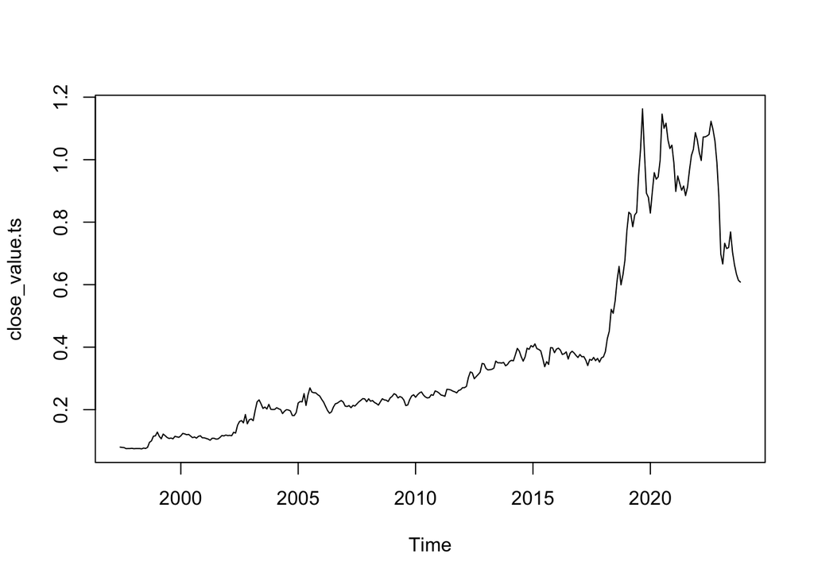

```r
#Monthly
close_value.ts <- ts(Amazon_clean$close, start = c(1997, 6), end = c(2023, 11), freq = 12)



plot(close_value.ts)
```

The distribution of the Adjusted close prices for the Amazon stock data from 2013 and S&P500

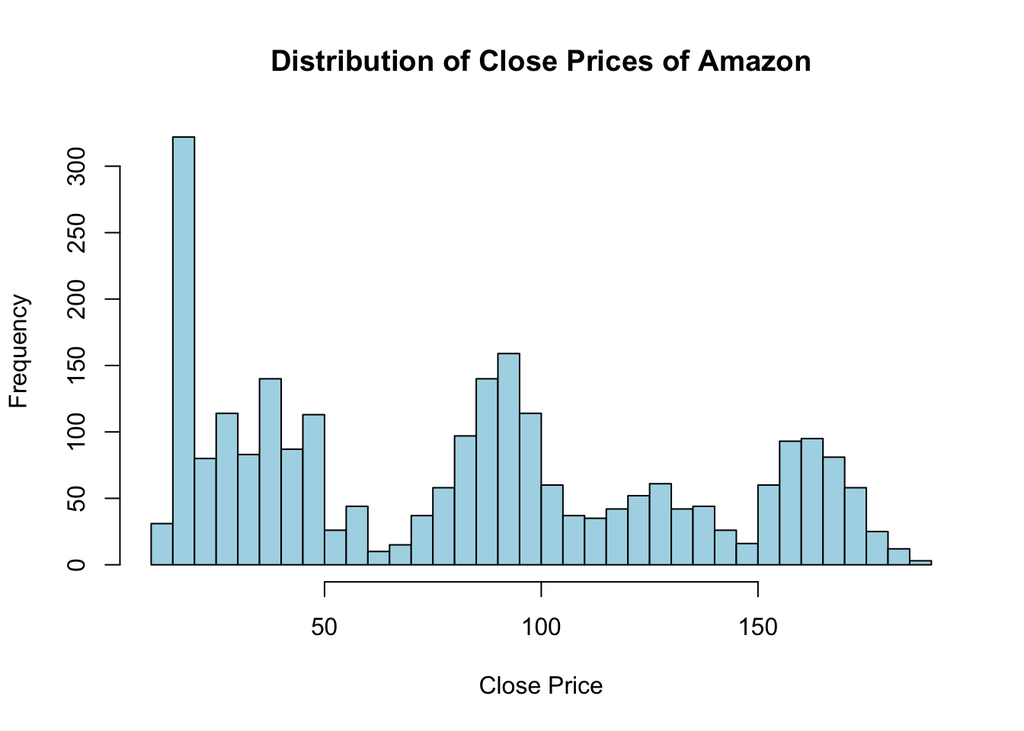

```r
# Amazon
par(mfrow=c(1,1), mar=c(5,4,4,2)+0.1)
hist_amazon <- hist(amazon_filter$close, breaks=50, col="lightblue", border="black",
                    main="Distribution of Close Prices of Amazon", xlab="Close Price", ylab="Frequency")
```

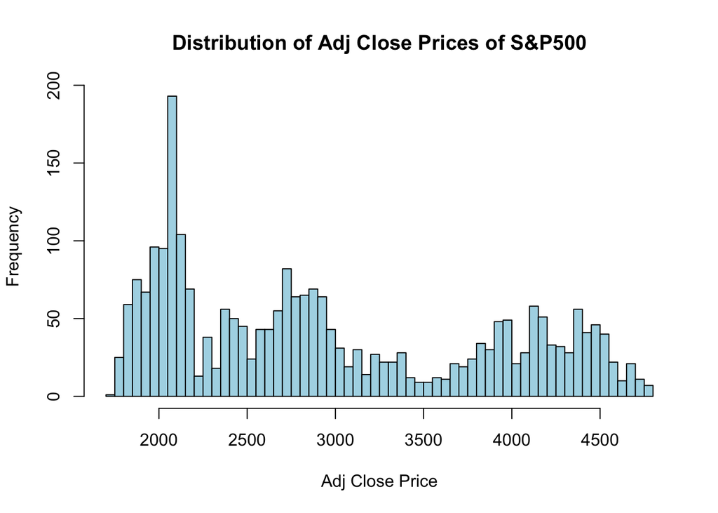

```r
# S&P500
par(mfrow=c(1,1), mar=c(5,4,4,2)+0.1)
hist_sp500 <- hist(sp_filter$Close.Last, breaks=50, col="lightblue", border="black",
                   main="Distribution of Adj Close Prices of S&P500", xlab="Adj Close Price", ylab="Frequency")
```

The histogram indicates how often different price ranges occurred over the dataset timeframe

Line Graph of closing price over time for Amazon and S&P data

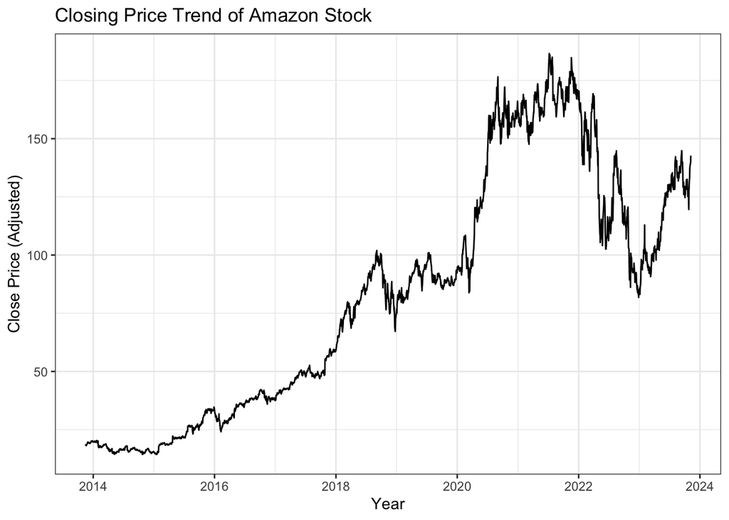

```r
#Amazon Data
theme_set(theme_minimal())


amazon_filter$date <- as.Date(amazon_filter$date)

# Plotting closing price over time
plot_amazon <- ggplot(data = amazon_filter, aes(x = date, y = close)) +
  geom_line() +
  labs(title = 'Closing Price Trend of Amazon Stock',
       x = 'Year',
       y = 'Close Price (Adjusted)') +
  theme_bw()

plot_amazon
```

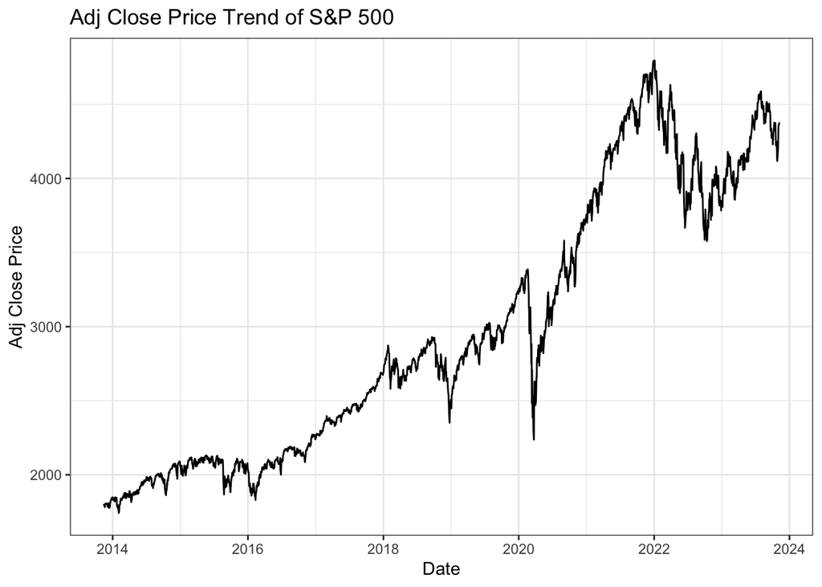

```r
#S&P 500
sp_filter$date <- as.Date(sp_filter$date, format = "%Y-%m-%d")

# Plotting closing price trend over time
plot_sp500 <- ggplot(data = sp_filter, aes(x = date, y = Close.Last)) +
  geom_line() +
  labs(title = 'Adj Close Price Trend of S&P 500',
       x = 'Date',
       y = 'Adj Close Price') +
  theme_bw()

plot_sp500
```

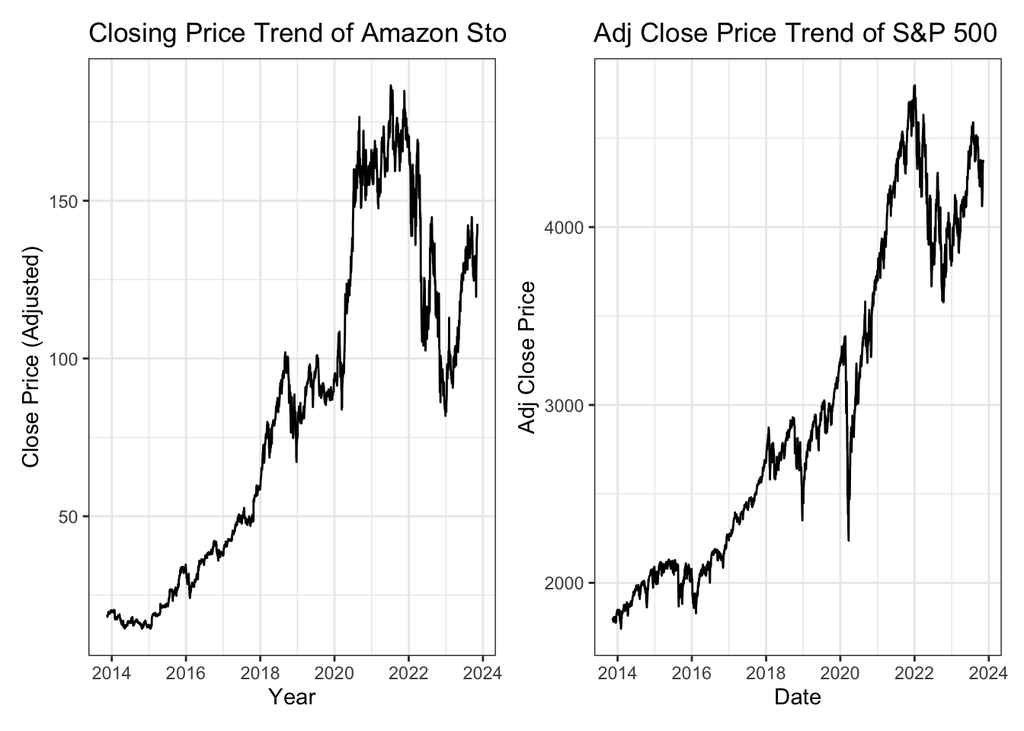

```r
# Arrange the plots side by side
together_plot <- plot_amazon + plot_sp500

together_plot
```

This line chart provides a clear view of how the closing price has changed, which can be useful for identifying trends, patterns, or stock’s performance.

Rolling Statistics line Graph

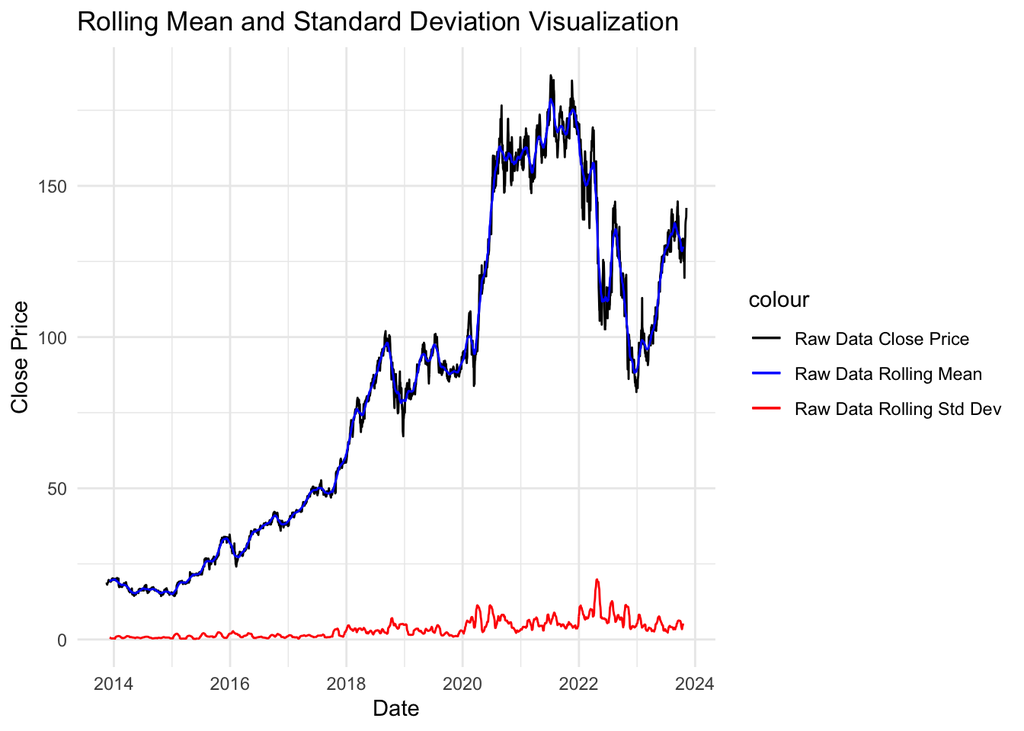

```r
amazon_filter$date <- as.Date(amazon_filter$date)

# Load required libraries
library(zoo)
library(ggplot2)

# Define rolling window
rolling_window <- 30

# Calculate rolling mean and standard deviation for 'close'
amazon_filter$rolling_mean <- rollmean(amazon_filter$close, k = rolling_window, fill = NA)
amazon_filter$rolling_std <- rollapply(amazon_filter$close, width = rolling_window, FUN = sd, fill = NA)

# Visualization
ggplot(amazon_filter, aes(x = date)) +
  geom_line(aes(y = close, color = "Raw Data Close Price")) +
  geom_line(aes(y = rolling_mean, color = "Raw Data Rolling Mean")) +
  geom_line(aes(y = rolling_std, color = "Raw Data Rolling Std Dev")) +
  labs(title = 'Rolling Mean and Standard Deviation Visualization',
       x = 'Date', y = 'Close Price') +
  scale_color_manual(values = c("Raw Data Close Price" = "black",
                                 "Raw Data Rolling Mean" = "blue",
                                 "Raw Data Rolling Std Dev" = "red")) +
  theme_minimal()
```

Calculating mean of closing price for Amazon

```r
# Compute the monthly mean of the 'close_value.ts' time series data using tapply and cycle functions
amazon.monthly <- tapply(close_value.ts, cycle(close_value.ts), mean)
amazon.monthly
```

```
##         1         2         3         4         5         6         7         8
## 0.3616000 0.3606404 0.3674865 0.3695474 0.3728237 0.3679796 0.3736130 0.3801247
##         9        10        11        12
## 0.3875556 0.3837593 0.3767920 0.3682846
```

```r
# Compute the annual mean of the 'close_value.ts' time series data using the aggregate function
amazon.annual <- aggregate(close_value.ts, FUN = mean)
amazon.annual
```

```
## Time Series:
## Start = 1997.417
## End = 2022.417
## Frequency = 1
##  [1] 0.07637917 0.10393333 0.11473333 0.11018333 0.11558750 0.17752083
##  [7] 0.20410417 0.20675000 0.23550000 0.21453750 0.22608750 0.23502917
## [13] 0.23884583 0.24842083 0.27183333 0.32481667 0.35673333 0.38855000
## [19] 0.37624583 0.37097083 0.38982639 0.68962778 0.94452778 1.01419722
## [25] 1.00343333 0.90350000
```

Correlation:

```r
# Calculate the correlation between 'Close.Last' in 'amazon_sp' and 'close' in 'amazon_sp'
corr_result <- cor(amazon_sp$Close.Last, amazon_sp$close)
corr_result
```

```
## [1] 0.9141689
```

```r
# Result - 0.914 indicates strong positive correlation between the variables Close.Last and close in your amazon_sp dataset.


# Display a summary of the correlation result
summary(corr_result)
```

```
##    Min. 1st Qu.  Median    Mean 3rd Qu.    Max.
##  0.9142  0.9142  0.9142  0.9142  0.9142  0.9142
```

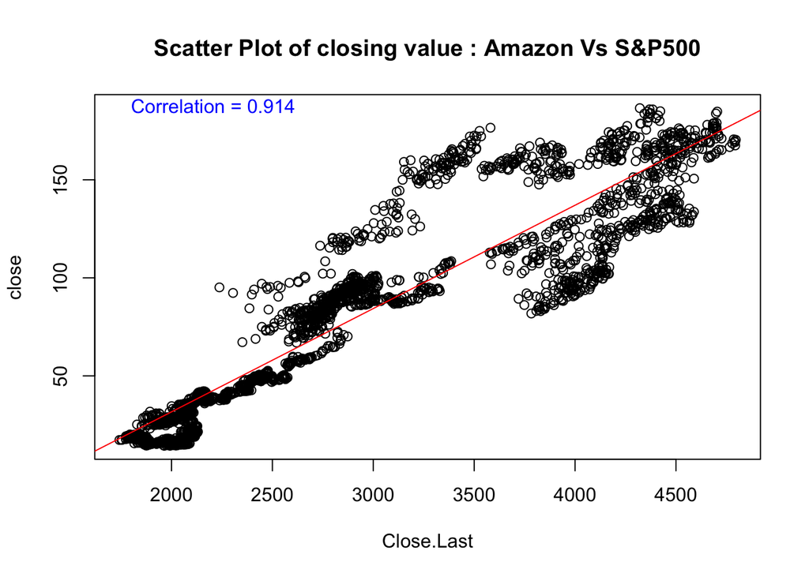

```r
# Scatter plot between 'Close.Last' and 'close' in 'Amazon' and 'S&P'
plot(amazon_sp$Close.Last, amazon_sp$close,
     xlab = "Close.Last", ylab = "close",
     main = "Scatter Plot of closing value : Amazon Vs S&P500")

# trendline
abline(lm(amazon_sp$close ~ amazon_sp$Close.Last), col = "red")
text(x = min(amazon_sp$Close.Last), y = max(amazon_sp$close),
     label = paste("Correlation =", round(corr_result, 3)),
     pos = 4, col = "blue")
```

Preparing training and validation time series data from ‘close_value.ts’ starting from June 1997, with 60 validation observations

```r
# Define the number of validation observations
nValid <- 60

# Calculating the number of training observations
nTrain <- length(close_value.ts) - nValid

# Training time series data from 'close_value.ts' starting from June 1997
train.ts <- window(close_value.ts, start = c(1997, 6), end = c(1997, nTrain+5))

# Validation time series data from 'close_value.ts' starting from the next observation after the training data
valid.ts <- window(close_value.ts, start = c(1997, nTrain + 6), end = c(1997, nTrain + nValid+5))

# Display the last few observations of the validation time series data
tail(valid.ts)
```

```
##            Jun       Jul       Aug       Sep       Oct       Nov
## 2023 0.7687333 0.7041667 0.6635333 0.6338667 0.6140667 0.6083333
```

```r
# Display the first few observations and the last few observations of the entire time series data
head(close_value.ts)
```

```
##          Jun     Jul     Aug     Sep     Oct     Nov
## 1997 0.08020 0.07915 0.07865 0.07525 0.07550 0.07550
```

```r
tail(close_value.ts)
```

```
##            Jun       Jul       Aug       Sep       Oct       Nov
## 2023 0.7687333 0.7041667 0.6635333 0.6338667 0.6140667 0.6083333
```

```r
# Display the total length of the time series data
length(close_value.ts)
```

```
## [1] 318
```

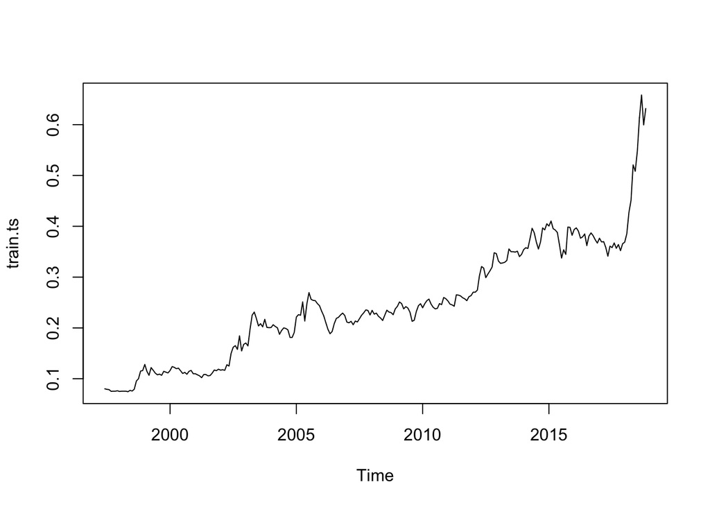

```r
# Plot the training time series data
plot(train.ts)
```

Model1 : Linear Regression

```r
# Fit a time series linear regression model using the train.ts data with trend and season as predictors
amazon_reg_linear <- tslm(train.ts ~ trend + season)
summary(amazon_reg_linear)
```

```
##
## Call:
## tslm(formula = train.ts ~ trend + season)
##
## Residuals:
##       Min        1Q    Median        3Q       Max
## -0.064599 -0.024340 -0.003522  0.015900  0.230281
##
## Coefficients:
##               Estimate Std. Error t value Pr(>|t|)
## (Intercept)  5.894e-02  9.631e-03   6.120 3.68e-09 ***
## trend        1.418e-03  3.313e-05  42.788  < 2e-16 ***
## season2     -8.502e-04  1.223e-02  -0.070    0.945
## season3     -7.075e-04  1.223e-02  -0.058    0.954
## season4      1.693e-03  1.223e-02   0.138    0.890
## season5      3.064e-03  1.223e-02   0.251    0.802
## season6      3.986e-03  1.209e-02   0.330    0.742
## season7      1.455e-03  1.209e-02   0.120    0.904
## season8      5.022e-03  1.209e-02   0.415    0.678
## season9      6.190e-03  1.209e-02   0.512    0.609
## season10     9.536e-03  1.209e-02   0.789    0.431
## season11     9.013e-03  1.209e-02   0.746    0.457
## season12    -7.554e-04  1.223e-02  -0.062    0.951
## ---
## Signif. codes:  0 '***' 0.001 '**' 0.01 '*' 0.05 '.' 0.1 ' ' 1
##
## Residual standard error: 0.03963 on 245 degrees of freedom
## Multiple R-squared:  0.8822, Adjusted R-squared:  0.8765
## F-statistic: 152.9 on 12 and 245 DF,  p-value: < 2.2e-16
```

```r
# Generate forecasts using the fitted linear regression model for the validation period
amazon_reg_linear_pred <- forecast(amazon_reg_linear, h = nValid, level = 0)
amazon_reg_linear_pred$mean
```

```
##            Jan       Feb       Mar       Apr       May       Jun       Jul
## 2018
## 2019 0.4275329 0.4281004 0.4296607 0.4334789 0.4362670 0.4386076 0.4374940
## 2020 0.4445447 0.4451122 0.4466725 0.4504907 0.4532788 0.4556194 0.4545058
## 2021 0.4615565 0.4621240 0.4636843 0.4675025 0.4702906 0.4726312 0.4715176
## 2022 0.4785683 0.4791358 0.4806961 0.4845143 0.4873024 0.4896430 0.4885294
## 2023 0.4955801 0.4961476 0.4977079 0.5015261 0.5043142 0.5066548 0.5055412
##            Aug       Sep       Oct       Nov       Dec
## 2018                                         0.4253599
## 2019 0.4424781 0.4450644 0.4498281 0.4507228 0.4423717
## 2020 0.4594899 0.4620762 0.4668399 0.4677346 0.4593835
## 2021 0.4765017 0.4790880 0.4838517 0.4847464 0.4763953
## 2022 0.4935134 0.4960998 0.5008634 0.5017581 0.4934071
## 2023 0.5105252 0.5131116 0.5178752 0.5187699
```

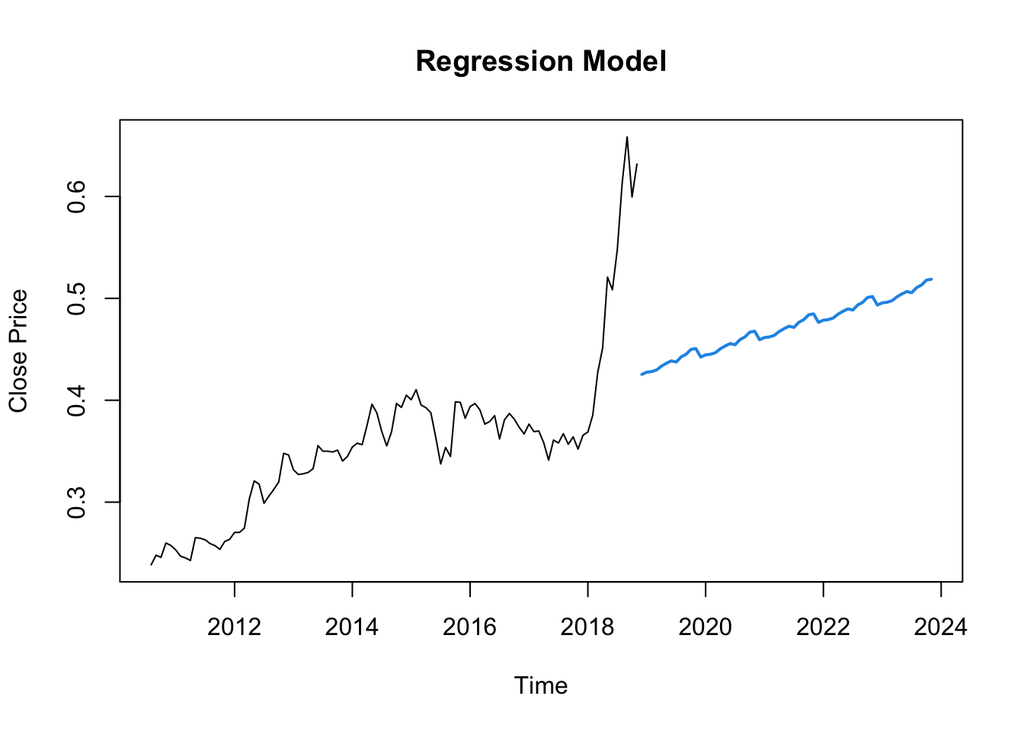

```r
# Plotting the forecast
plot(amazon_reg_linear_pred, main = 'Regression Model', xlab = 'Time', ylab = 'Close Price', include = 100)
```

Model 2:Polynomial Trend and seasonality

```r
# Define and train the model
amazon_poly_season <- tslm(train.ts ~ trend + I(trend^2) + season)
summary(amazon_poly_season)
```

```
##
## Call:
## tslm(formula = train.ts ~ trend + I(trend^2) + season)
##
## Residuals:
##       Min        1Q    Median        3Q       Max
## -0.082770 -0.022344 -0.004266  0.014279  0.206413
##
## Coefficients:
##               Estimate Std. Error t value Pr(>|t|)
## (Intercept)  8.581e-02  1.071e-02   8.014 4.58e-14 ***
## trend        8.119e-04  1.273e-04   6.380 8.85e-10 ***
## I(trend^2)   2.339e-06  4.760e-07   4.914 1.64e-06 ***
## season2     -8.455e-04  1.169e-02  -0.072    0.942
## season3     -7.028e-04  1.169e-02  -0.060    0.952
## season4      1.693e-03  1.169e-02   0.145    0.885
## season5      3.054e-03  1.169e-02   0.261    0.794
## season6      2.770e-03  1.156e-02   0.240    0.811
## season7      2.484e-04  1.156e-02   0.021    0.983
## season8      3.820e-03  1.156e-02   0.330    0.741
## season9      4.988e-03  1.156e-02   0.432    0.666
## season10     8.330e-03  1.156e-02   0.721    0.472
## season11     7.797e-03  1.156e-02   0.675    0.501
## season12    -7.647e-04  1.169e-02  -0.065    0.948
## ---
## Signif. codes:  0 '***' 0.001 '**' 0.01 '*' 0.05 '.' 0.1 ' ' 1
##
## Residual standard error: 0.03788 on 244 degrees of freedom
## Multiple R-squared:  0.8928, Adjusted R-squared:  0.8871
## F-statistic: 156.4 on 13 and 244 DF,  p-value: < 2.2e-16
```

```r
# Generate forecasts
amazon_poly_season_pred <- forecast(amazon_poly_season, h = nValid, level = 0)
amazon_poly_season_pred$mean
```

```
##            Jan       Feb       Mar       Apr       May       Jun       Jul
## 2018
## 2019 0.4550070 0.4561918 0.4583696 0.4628052 0.4662107 0.4679760 0.4675078
## 2020 0.4796801 0.4809211 0.4831549 0.4876467 0.4911083 0.4929297 0.4925177
## 2021 0.5050267 0.5063238 0.5086138 0.5131617 0.5166794 0.5185570 0.5182010
## 2022 0.5310469 0.5324001 0.5347462 0.5393502 0.5429241 0.5448577 0.5445579
## 2023 0.5577405 0.5591499 0.5615521 0.5662123 0.5698423 0.5718320 0.5715884
##            Aug       Sep       Oct       Nov       Dec
## 2018                                         0.4522166
## 2019 0.4731373 0.4763692 0.4817783 0.4833184 0.4768336
## 2020 0.4982033 0.5014913 0.5069565 0.5085528 0.5021241
## 2021 0.5239428 0.5272869 0.5328083 0.5344607 0.5280881
## 2022 0.5503559 0.5537561 0.5593336 0.5610421 0.5547256
## 2023 0.5774424 0.5808988 0.5865324 0.5882970
```

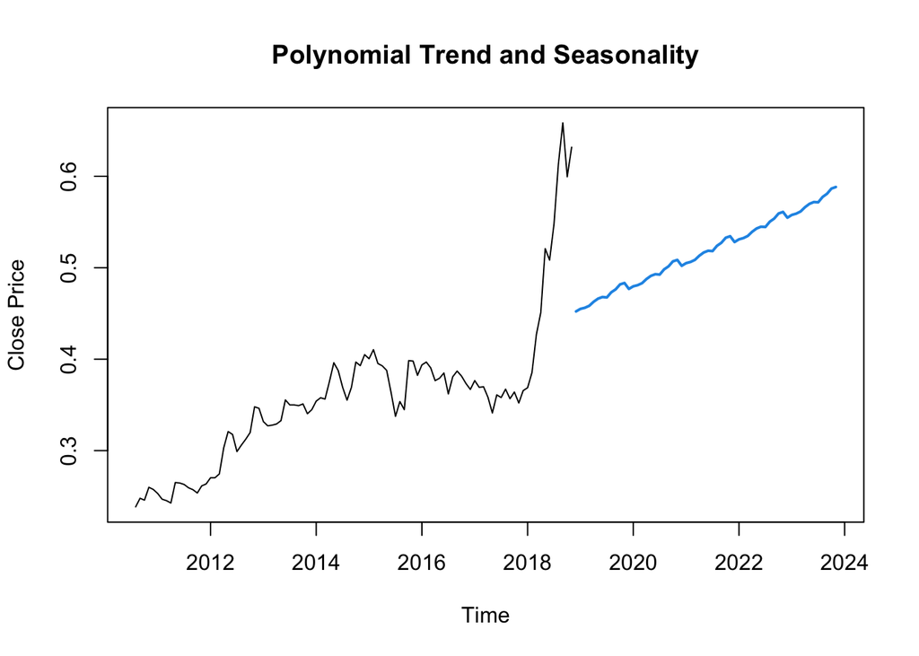

```r
# Plotting the forecast
plot(amazon_poly_season_pred, main = 'Polynomial Trend and Seasonality', xlab = 'Time', ylab = 'Close Price', include = 100)
```

Model3 : ETS - ANN

```r
# Fit an Exponential Smoothing State model
ets_ann <- ets(train.ts, model = "ANN")
summary(ets_ann)
```

```
## ETS(A,N,N)
##
## Call:
##  ets(y = train.ts, model = "ANN")
##
##   Smoothing parameters:
##     alpha = 0.9999
##
##   Initial states:
##     l = 0.0802
##
##   sigma:  0.0142
##
##       AIC      AICc       BIC
## -759.5325 -759.4380 -748.8736
##
## Training set error measures:
##                       ME       RMSE         MAE      MPE     MAPE      MASE
## Training set 0.002138097 0.01412132 0.009225328 0.664181 3.693544 0.2979631
##                    ACF1
## Training set 0.01660132
```

```r
# Generate forecasts using the fitted ETS model for the validation period
ets_ann_pred <- forecast(ets_ann, h= nValid, level = 0)

# Extract and display the mean
ets_ann_pred$mean
```

```
##            Jan       Feb       Mar       Apr       May       Jun       Jul
## 2018
## 2019 0.6317634 0.6317634 0.6317634 0.6317634 0.6317634 0.6317634 0.6317634
## 2020 0.6317634 0.6317634 0.6317634 0.6317634 0.6317634 0.6317634 0.6317634
## 2021 0.6317634 0.6317634 0.6317634 0.6317634 0.6317634 0.6317634 0.6317634
## 2022 0.6317634 0.6317634 0.6317634 0.6317634 0.6317634 0.6317634 0.6317634
## 2023 0.6317634 0.6317634 0.6317634 0.6317634 0.6317634 0.6317634 0.6317634
##            Aug       Sep       Oct       Nov       Dec
## 2018                                         0.6317634
## 2019 0.6317634 0.6317634 0.6317634 0.6317634 0.6317634
## 2020 0.6317634 0.6317634 0.6317634 0.6317634 0.6317634
## 2021 0.6317634 0.6317634 0.6317634 0.6317634 0.6317634
## 2022 0.6317634 0.6317634 0.6317634 0.6317634 0.6317634
## 2023 0.6317634 0.6317634 0.6317634 0.6317634
```

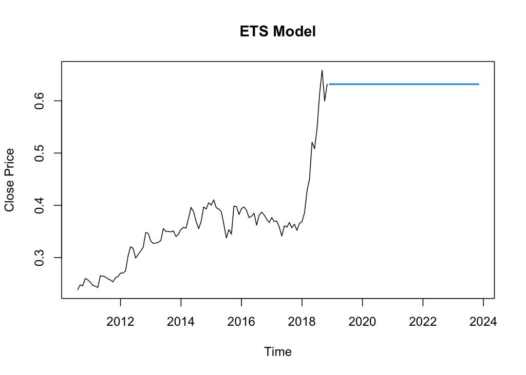

```r
#plot the graph
plot(ets_ann_pred, main = 'ETS Model', xlab = 'Time', ylab = 'Close Price', include = 100)
```

Model4 : ARIMA

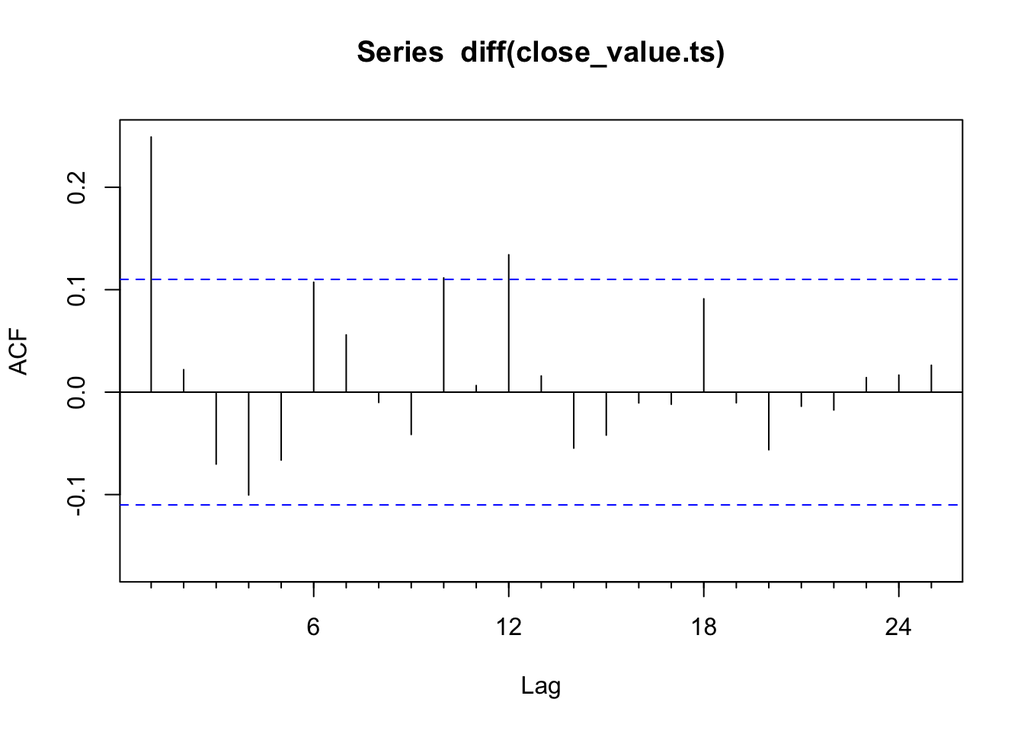

```r
Acf(diff(close_value.ts))
```

```r
#The model is not a random walk


# Fit ARIMA(1,1,1) model- The choice of ARIMA(1,1,1) for Amazon stock prediction signifies the inclusion of one autoregressive term, one differencing, and one moving average term.
amazon.AR1 <- Arima(diff(close_value.ts), order = c(1, 1, 1))
summary(amazon.AR1)
```

```
## Series: diff(close_value.ts)
## ARIMA(1,1,1)
##
## Coefficients:
##          ar1      ma1
##       0.2523  -1.0000
## s.e.  0.0545   0.0101
##
## sigma^2 = 0.0008616:  log likelihood = 664.96
## AIC=-1323.92   AICc=-1323.84   BIC=-1312.65
##
## Training set error measures:
##                        ME       RMSE        MAE MPE MAPE      MASE       ACF1
## Training set 0.0001334709 0.02921354 0.01672501 NaN  Inf 0.7339504 0.00758899
```

```r
#Coefficients:
#         ar1      ma1
#      0.2523  -1.0000
#s.e.  0.0545   0.0101

# Fit an auto ARIMA model to the training data
arima_model <- auto.arima(train.ts)
summary(arima_model)
```

```
## Series: train.ts
## ARIMA(0,1,0) with drift
##
## Coefficients:
##        drift
##       0.0021
## s.e.  0.0009
##
## sigma^2 = 0.0001963:  log likelihood = 732.66
## AIC=-1461.33   AICc=-1461.28   BIC=-1454.23
##
## Training set error measures:
##                        ME       RMSE         MAE       MPE     MAPE      MASE
## Training set 3.025341e-07 0.01395786 0.009428611 -0.442458 3.891583 0.3045288
##                    ACF1
## Training set 0.01636387
```

```r
# Generate forecasts using the fitted ARIMA model for the validation period
arima_train_pred <- forecast(arima_model, h = nValid, level = 0)
arima_train_pred
```

```
##          Point Forecast      Lo 0      Hi 0
## Dec 2018      0.6339128 0.6339128 0.6339128
## Jan 2019      0.6360590 0.6360590 0.6360590
## Feb 2019      0.6382052 0.6382052 0.6382052
## Mar 2019      0.6403514 0.6403514 0.6403514
## Apr 2019      0.6424975 0.6424975 0.6424975
## May 2019      0.6446437 0.6446437 0.6446437
## Jun 2019      0.6467899 0.6467899 0.6467899
## Jul 2019      0.6489361 0.6489361 0.6489361
## Aug 2019      0.6510822 0.6510822 0.6510822
## Sep 2019      0.6532284 0.6532284 0.6532284
## Oct 2019      0.6553746 0.6553746 0.6553746
## Nov 2019      0.6575208 0.6575208 0.6575208
## Dec 2019      0.6596669 0.6596669 0.6596669
## Jan 2020      0.6618131 0.6618131 0.6618131
## Feb 2020      0.6639593 0.6639593 0.6639593
## Mar 2020      0.6661054 0.6661054 0.6661054
## Apr 2020      0.6682516 0.6682516 0.6682516
## May 2020      0.6703978 0.6703978 0.6703978
## Jun 2020      0.6725440 0.6725440 0.6725440
## Jul 2020      0.6746901 0.6746901 0.6746901
## Aug 2020      0.6768363 0.6768363 0.6768363
## Sep 2020      0.6789825 0.6789825 0.6789825
## Oct 2020      0.6811287 0.6811287 0.6811287
## Nov 2020      0.6832748 0.6832748 0.6832748
## Dec 2020      0.6854210 0.6854210 0.6854210
## Jan 2021      0.6875672 0.6875672 0.6875672
## Feb 2021      0.6897134 0.6897134 0.6897134
## Mar 2021      0.6918595 0.6918595 0.6918595
## Apr 2021      0.6940057 0.6940057 0.6940057
## May 2021      0.6961519 0.6961519 0.6961519
## Jun 2021      0.6982981 0.6982981 0.6982981
## Jul 2021      0.7004442 0.7004442 0.7004442
## Aug 2021      0.7025904 0.7025904 0.7025904
## Sep 2021      0.7047366 0.7047366 0.7047366
## Oct 2021      0.7068827 0.7068827 0.7068827
## Nov 2021      0.7090289 0.7090289 0.7090289
## Dec 2021      0.7111751 0.7111751 0.7111751
## Jan 2022      0.7133213 0.7133213 0.7133213
## Feb 2022      0.7154674 0.7154674 0.7154674
## Mar 2022      0.7176136 0.7176136 0.7176136
## Apr 2022      0.7197598 0.7197598 0.7197598
## May 2022      0.7219060 0.7219060 0.7219060
## Jun 2022      0.7240521 0.7240521 0.7240521
## Jul 2022      0.7261983 0.7261983 0.7261983
## Aug 2022      0.7283445 0.7283445 0.7283445
## Sep 2022      0.7304907 0.7304907 0.7304907
## Oct 2022      0.7326368 0.7326368 0.7326368
## Nov 2022      0.7347830 0.7347830 0.7347830
## Dec 2022      0.7369292 0.7369292 0.7369292
## Jan 2023      0.7390754 0.7390754 0.7390754
## Feb 2023      0.7412215 0.7412215 0.7412215
## Mar 2023      0.7433677 0.7433677 0.7433677
## Apr 2023      0.7455139 0.7455139 0.7455139
## May 2023      0.7476601 0.7476601 0.7476601
## Jun 2023      0.7498062 0.7498062 0.7498062
## Jul 2023      0.7519524 0.7519524 0.7519524
## Aug 2023      0.7540986 0.7540986 0.7540986
## Sep 2023      0.7562447 0.7562447 0.7562447
## Oct 2023      0.7583909 0.7583909 0.7583909
## Nov 2023      0.7605371 0.7605371 0.7605371
```

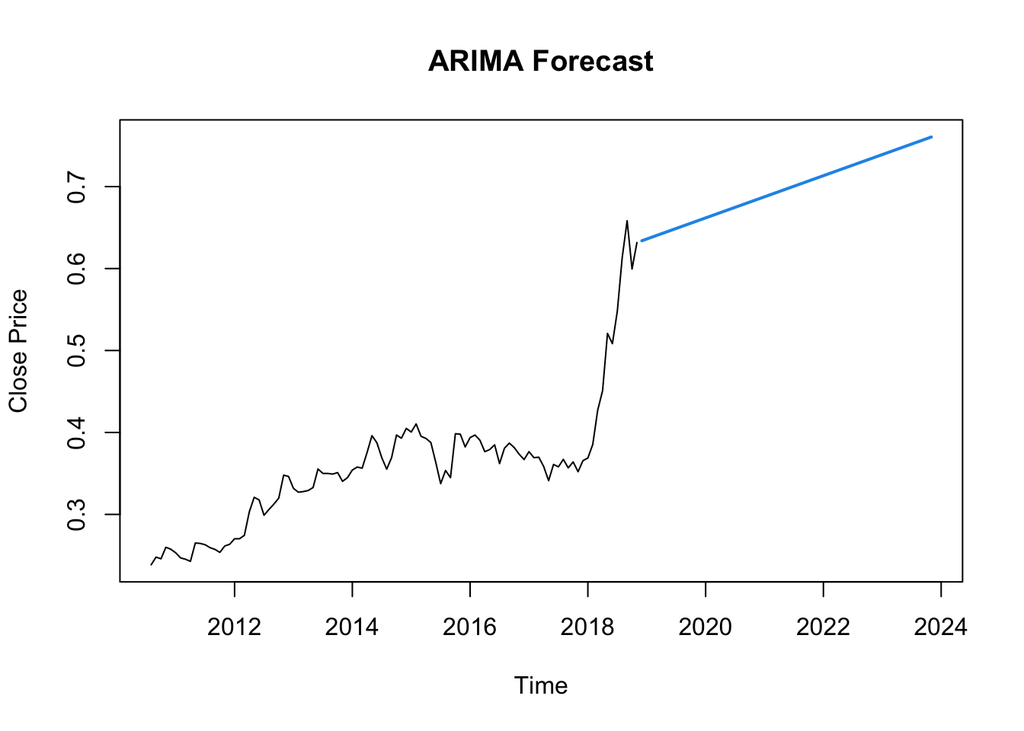

```r
# Plot the ARIMA forecasts
plot(arima_train_pred, main = 'ARIMA Forecast', xlab = 'Time', ylab = 'Close Price', include = 100)
```

Check Accuracy for all

```r
accuracy(amazon_reg_linear_pred$mean, valid.ts)
```

```
##                 ME      RMSE       MAE      MPE     MAPE      ACF1 Theil's U
## Test set 0.4472063 0.4738309 0.4472063 47.00028 47.00028 0.8632156  7.133371
```

```r
accuracy(amazon_poly_season_pred$mean, valid.ts)
```

```
##                 ME      RMSE       MAE      MPE     MAPE      ACF1 Theil's U
## Test set 0.4003404 0.4320813 0.4003404 41.64803 41.64803 0.8698569  6.468164
```

```r
accuracy(ets_ann_pred$mean, valid.ts)
```

```
##                ME      RMSE       MAE      MPE     MAPE      ACF1 Theil's U
## Test set 0.286516 0.3230756 0.2878869 29.12436 29.34881 0.8543776  4.734253
```

```r
accuracy(arima_train_pred$mean, valid.ts)
```

```
##                 ME      RMSE       MAE      MPE     MAPE    ACF1 Theil's U
## Test set 0.2210545 0.2742038 0.2458277 21.54106 25.37826 0.87119  4.060988
```

Prediction

```r
# Fit ARIMA(1,1,1) model with seasonal differencing
arima_all <- Arima(close_value.ts, order = c(1,1,1), seasonal = c(0,1,1))
summary(arima_all)
```

```
## Series: close_value.ts
## ARIMA(1,1,1)(0,1,1)[12]
##
## Coefficients:
##          ar1     ma1     sma1
##       0.1481  0.1019  -0.8845
## s.e.  0.1823  0.1801   0.0495
##
## sigma^2 = 0.0009247:  log likelihood = 624.94
## AIC=-1241.87   AICc=-1241.74   BIC=-1226.99
##
## Training set error measures:
##                        ME       RMSE        MAE         MPE     MAPE      MASE
## Training set -0.000167641 0.02963355 0.01705588 -0.01073988 4.173268 0.2559024
##                     ACF1
## Training set 0.001987013
```

```r
# Number of future predictions
nFuture <- 24

# Generate forecasts for the future using the ARIMA model
arima_train_pred_forecast <- forecast(arima_all, h = nFuture, level = 95)
arima_train_pred_forecast
```

```
##          Point Forecast     Lo 95     Hi 95
## Dec 2023      0.6077536 0.5481432 0.6673640
## Jan 2024      0.5833551 0.4879299 0.6787803
## Feb 2024      0.5780568 0.4556130 0.7005005
## Mar 2024      0.5939939 0.4493244 0.7386634
## Apr 2024      0.5950220 0.4310905 0.7589535
## May 2024      0.6012687 0.4201088 0.7824286
## Jun 2024      0.6137517 0.4168649 0.8106385
## Jul 2024      0.6233670 0.4119208 0.8348132
## Aug 2024      0.6336093 0.4085436 0.8586750
## Sep 2024      0.6459083 0.4080015 0.8838152
## Oct 2024      0.6306035 0.3805141 0.8806930
## Nov 2024      0.6151228 0.3534171 0.8768284
## Dec 2024      0.6120888 0.3372305 0.8869472
## Jan 2025      0.5873268 0.2994077 0.8752459
## Feb 2025      0.5819746 0.2814890 0.8824602
## Mar 2025      0.5979037 0.2853460 0.9104614
## Apr 2025      0.5989307 0.2747486 0.9231127
## May 2025      0.6051772 0.2697733 0.9405811
## Jun 2025      0.6176602 0.2713982 0.9639222
## Jul 2025      0.6272754 0.2704873 0.9840636
## Aug 2025      0.6375178 0.2705053 1.0045303
## Sep 2025      0.6498168 0.2728571 1.0267764
## Oct 2025      0.6345120 0.2478610 1.0211630
## Nov 2025      0.6190312 0.2229259 1.0151365
```

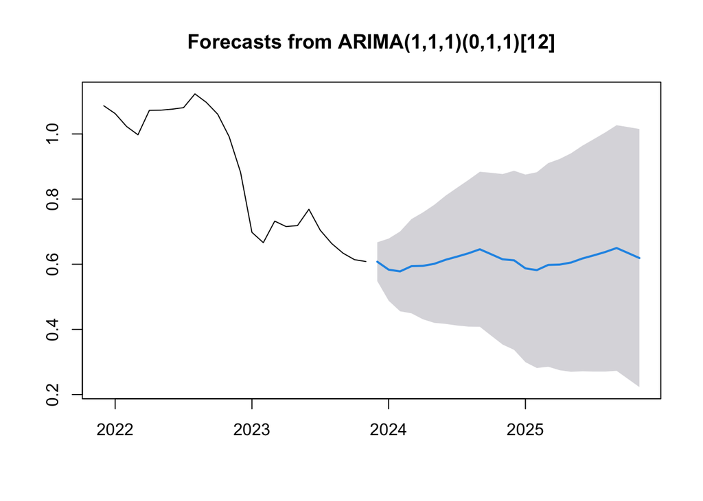

```r
# Plot the ARIMA forecasts for the future
plot(arima_train_pred_forecast, include = nFuture)
```

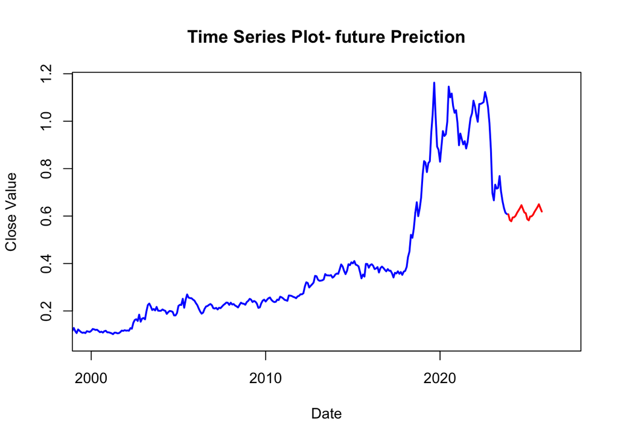

```r
# Convert the time index of close_value.ts to Date format
close_value_dates <- as.Date(time(close_value.ts))

# Set start_date and end_date based on your data
start_date <- as.Date("2000-01-01")
end_date <- as.Date("2026-12-31")

# Plot the time series
plot(close_value_dates, close_value.ts, col = "blue", lwd = 2, type = "l",
     main = "Time Series Plot- future Preiction", ylim = c(min(close_value.ts, arima_train_pred_forecast$mean), max(close_value.ts, arima_train_pred_forecast$mean)),
     xlim = c(start_date, end_date), xlab = "Date", ylab = "Close Value")
lines(as.Date(time(arima_train_pred_forecast$mean)), arima_train_pred_forecast$mean, col = "red", lwd = 2)
```

```r
arima_train_pred_forecast
```

```
##          Point Forecast     Lo 95     Hi 95
## Dec 2023      0.6077536 0.5481432 0.6673640
## Jan 2024      0.5833551 0.4879299 0.6787803
## Feb 2024      0.5780568 0.4556130 0.7005005
## Mar 2024      0.5939939 0.4493244 0.7386634
## Apr 2024      0.5950220 0.4310905 0.7589535
## May 2024      0.6012687 0.4201088 0.7824286
## Jun 2024      0.6137517 0.4168649 0.8106385
## Jul 2024      0.6233670 0.4119208 0.8348132
## Aug 2024      0.6336093 0.4085436 0.8586750
## Sep 2024      0.6459083 0.4080015 0.8838152
## Oct 2024      0.6306035 0.3805141 0.8806930
## Nov 2024      0.6151228 0.3534171 0.8768284
## Dec 2024      0.6120888 0.3372305 0.8869472
## Jan 2025      0.5873268 0.2994077 0.8752459
## Feb 2025      0.5819746 0.2814890 0.8824602
## Mar 2025      0.5979037 0.2853460 0.9104614
## Apr 2025      0.5989307 0.2747486 0.9231127
## May 2025      0.6051772 0.2697733 0.9405811
## Jun 2025      0.6176602 0.2713982 0.9639222
## Jul 2025      0.6272754 0.2704873 0.9840636
## Aug 2025      0.6375178 0.2705053 1.0045303
## Sep 2025      0.6498168 0.2728571 1.0267764
## Oct 2025      0.6345120 0.2478610 1.0211630
## Nov 2025      0.6190312 0.2229259 1.0151365
```

Visualization:

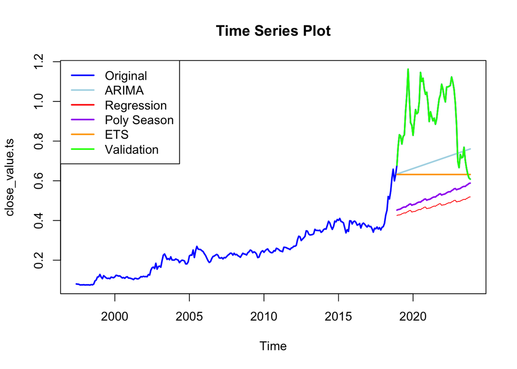

```r
# Plot the time series
plot(close_value.ts, col = "blue", lwd = 2, type = "l", main = "Time Series Plot")

lines(arima_train_pred$mean, col = "lightblue", lwd = 2)
lines(amazon_reg_linear_pred$mean, col = "red")
lines(amazon_poly_season_pred$mean, col = "purple", lwd = 2)
lines(ets_ann_pred$mean, col = "orange", lwd = 2)
lines(valid.ts, col = "green", lwd = 2)

legend("topleft", legend = c("Original", "ARIMA","Regression", "Poly Season", "ETS", "Validation"), col = c("blue", "lightblue","red", "purple", "orange", "green"), lty = 1, lwd = 2)
```

Comparing test data for the last 5 months to our prediction output: ARIMA Preparing the train, valid and test data:

```r
# Define the number of validation observations
nTest <- 5
nValid1 <- 60


# Calculating the number of training observations
nTrain1 <- length(close_value.ts) - nValid1 - nTest
nTrain1
```

```
## [1] 253
```

```r
# Training time series data from 'close_value.ts' starting from June 1997
train.ts1 <- window(close_value.ts, start = c(1997, 6), end = c(1997, nTrain1+5))
train.ts1
```

```
##            Jan       Feb       Mar       Apr       May       Jun       Jul
## 1997                                                   0.0802000 0.0791500
## 1998 0.0750000 0.0755000 0.0755000 0.0755000 0.0745000 0.0771000 0.0758000
## 1999 0.1281500 0.1146000 0.1067500 0.1219000 0.1166500 0.1109500 0.1078000
## 2000 0.1161500 0.1239500 0.1224000 0.1198000 0.1208500 0.1156500 0.1104000
## 2001 0.1099000 0.1078000 0.1057500 0.1021000 0.1083500 0.1083500 0.1057500
## 2002 0.1169500 0.1177000 0.1166500 0.1276000 0.1250000 0.1500000 0.1620000
## 2003 0.1703000 0.1646000 0.1974000 0.2250000 0.2312500 0.2187500 0.2039000
## 2004 0.2008000 0.2062500 0.2028500 0.2002500 0.1875000 0.1950500 0.2000000
## 2005 0.2213500 0.2260500 0.2250000 0.2513000 0.2135500 0.2474000 0.2695500
## 2006 0.2330500 0.2239500 0.2104000 0.1974000 0.1885500 0.1929500 0.2083500
## 2007 0.2114500 0.2101500 0.2130000 0.2062500 0.2135500 0.2117000 0.2182500
## 2008 0.2344000 0.2271000 0.2291500 0.2229000 0.2195500 0.2146000 0.2250000
## 2009 0.2424500 0.2510500 0.2479000 0.2375000 0.2419500 0.2390500 0.2307500
## 2010 0.2396000 0.2476500 0.2536500 0.2567500 0.2469000 0.2406500 0.2375000
```

[output cut: 31 more lines]

```r
# Validation time series data from 'close_value.ts' for the last 6 months
valid.ts1 <- window(close_value.ts, start = c(1997, nTrain1 +6), end = c(1997, nTrain1 + nValid1+5))
valid.ts1
```

```
##            Jan       Feb       Mar       Apr       May       Jun       Jul
## 2018                                                             0.5479333
## 2019 0.7724000 0.8317667 0.8255333 0.7854000 0.8229333 0.8312333 0.9510333
## 2020 0.8291667 0.8968667 0.9583333 0.9375000 0.9448000 0.9984333 1.1458333
## 2021 0.9911333 0.8984333 0.9479333 0.9239667 0.9021000 0.9156333 0.8849000
## 2022 1.0625000 1.0229333 0.9974000 1.0724000 1.0729333 1.0760333 1.0807333
## 2023 0.6979333 0.6662667 0.7323000 0.7156333 0.7187667 0.7687333
##            Aug       Sep       Oct       Nov       Dec
## 2018 0.6135333 0.6583333 0.5994667 0.6317667 0.6781333
## 2019 1.0333333 1.1625000 1.0177000 0.8927000 0.8791667
## 2020 1.1005333 1.1166667 1.0635333 1.0354333 1.0463667
## 2021 0.9125000 0.9666667 1.0135333 1.0333333 1.0864667
## 2022 1.1229333 1.0968667 1.0604333 0.9916667 0.8824333
## 2023
```

```r
# Test time series data for the last 6 months
test.ts1 <- window(close_value.ts, start = c(1997, nTrain1 + nValid1 +6), end = c(2023, 11))
test.ts1
```

```
##            Jul       Aug       Sep       Oct       Nov
## 2023 0.7041667 0.6635333 0.6338667 0.6140667 0.6083333
```

Running ARIMA Model and predicting future of 5 months to compare with actual data

```r
# Fit an auto ARIMA model to the training data
arima_model_compare <- auto.arima(train.ts1)
summary(arima_model_compare)
```

```
## Series: train.ts1
## ARIMA(0,1,0) with drift
##
## Coefficients:
##        drift
##       0.0017
## s.e.  0.0008
##
## sigma^2 = 0.0001527:  log likelihood = 750.08
## AIC=-1496.15   AICc=-1496.1   BIC=-1489.09
##
## Training set error measures:
##                        ME       RMSE         MAE        MPE     MAPE      MASE
## Training set 3.102807e-07 0.01230914 0.008616233 -0.2895751 3.757418 0.3263101
##                    ACF1
## Training set 0.01793558
```

```r
# Generate forecasts using the fitted ARIMA model for the validation period
arima_train_pred_compare <- forecast(arima_model_compare, h = nValid1, level = 0)
arima_train_pred_compare
```

```
##          Point Forecast      Lo 0      Hi 0
## Jul 2018      0.5100323 0.5100323 0.5100323
## Aug 2018      0.5117312 0.5117312 0.5117312
## Sep 2018      0.5134302 0.5134302 0.5134302
## Oct 2018      0.5151291 0.5151291 0.5151291
## Nov 2018      0.5168280 0.5168280 0.5168280
## Dec 2018      0.5185270 0.5185270 0.5185270
## Jan 2019      0.5202259 0.5202259 0.5202259
## Feb 2019      0.5219249 0.5219249 0.5219249
## Mar 2019      0.5236238 0.5236238 0.5236238
## Apr 2019      0.5253228 0.5253228 0.5253228
## May 2019      0.5270217 0.5270217 0.5270217
## Jun 2019      0.5287206 0.5287206 0.5287206
## Jul 2019      0.5304196 0.5304196 0.5304196
## Aug 2019      0.5321185 0.5321185 0.5321185
## Sep 2019      0.5338175 0.5338175 0.5338175
## Oct 2019      0.5355164 0.5355164 0.5355164
## Nov 2019      0.5372153 0.5372153 0.5372153
## Dec 2019      0.5389143 0.5389143 0.5389143
## Jan 2020      0.5406132 0.5406132 0.5406132
## Feb 2020      0.5423122 0.5423122 0.5423122
## Mar 2020      0.5440111 0.5440111 0.5440111
## Apr 2020      0.5457101 0.5457101 0.5457101
## May 2020      0.5474090 0.5474090 0.5474090
## Jun 2020      0.5491079 0.5491079 0.5491079
## Jul 2020      0.5508069 0.5508069 0.5508069
## Aug 2020      0.5525058 0.5525058 0.5525058
## Sep 2020      0.5542048 0.5542048 0.5542048
## Oct 2020      0.5559037 0.5559037 0.5559037
## Nov 2020      0.5576026 0.5576026 0.5576026
## Dec 2020      0.5593016 0.5593016 0.5593016
## Jan 2021      0.5610005 0.5610005 0.5610005
## Feb 2021      0.5626995 0.5626995 0.5626995
## Mar 2021      0.5643984 0.5643984 0.5643984
## Apr 2021      0.5660974 0.5660974 0.5660974
## May 2021      0.5677963 0.5677963 0.5677963
## Jun 2021      0.5694952 0.5694952 0.5694952
## Jul 2021      0.5711942 0.5711942 0.5711942
## Aug 2021      0.5728931 0.5728931 0.5728931
## Sep 2021      0.5745921 0.5745921 0.5745921
## Oct 2021      0.5762910 0.5762910 0.5762910
## Nov 2021      0.5779899 0.5779899 0.5779899
## Dec 2021      0.5796889 0.5796889 0.5796889
## Jan 2022      0.5813878 0.5813878 0.5813878
## Feb 2022      0.5830868 0.5830868 0.5830868
## Mar 2022      0.5847857 0.5847857 0.5847857
## Apr 2022      0.5864847 0.5864847 0.5864847
## May 2022      0.5881836 0.5881836 0.5881836
## Jun 2022      0.5898825 0.5898825 0.5898825
## Jul 2022      0.5915815 0.5915815 0.5915815
## Aug 2022      0.5932804 0.5932804 0.5932804
## Sep 2022      0.5949794 0.5949794 0.5949794
## Oct 2022      0.5966783 0.5966783 0.5966783
## Nov 2022      0.5983772 0.5983772 0.5983772
## Dec 2022      0.6000762 0.6000762 0.6000762
## Jan 2023      0.6017751 0.6017751 0.6017751
## Feb 2023      0.6034741 0.6034741 0.6034741
## Mar 2023      0.6051730 0.6051730 0.6051730
## Apr 2023      0.6068720 0.6068720 0.6068720
## May 2023      0.6085709 0.6085709 0.6085709
## Jun 2023      0.6102698 0.6102698 0.6102698
```

```r
#starts from july 2018 and end in 2023 June : output

# Fit ARIMA(1,1,1) model with seasonal differencing
arima_all_compare <- Arima(valid.ts1, order = c(1,1,1), seasonal = c(1,1,0))
summary(arima_all_compare)
```

```
## Series: valid.ts1
## ARIMA(1,1,1)(1,1,0)[12]
##
## Coefficients:
##          ar1     ma1     sar1
##       0.0107  0.2953  -0.4203
## s.e.  0.4196  0.3968   0.1438
##
## sigma^2 = 0.005338:  log likelihood = 56.62
## AIC=-105.24   AICc=-104.29   BIC=-97.84
##
## Training set error measures:
##                        ME       RMSE        MAE       MPE     MAPE      MASE
## Training set -0.009966972 0.06256381 0.04467256 -1.157211 4.793351 0.2637668
##                    ACF1
## Training set -0.0253622
```

```r
# Number of future predictions
nFuture <- 5

# Generate forecasts for the future using the ARIMA model
arima_future_pred_compare <- forecast(arima_all_compare, h = nFuture, level = 95)
arima_future_pred_compare
```

```
##          Point Forecast     Lo 95     Hi 95
## Jul 2023      0.7687901 0.6255975 0.9119827
## Aug 2023      0.8049632 0.5694328 1.0404936
## Sep 2023      0.8126209 0.5115884 1.1136535
## Oct 2023      0.8111998 0.4565613 1.1658384
## Nov 2023      0.7796590 0.3785151 1.1808029
```

```r
# Extract mean values from ARIMA forecast
arima_forecast_mean <- as.data.frame(arima_future_pred_compare$mean)


# Create a table with the mean values from ARIMA forecast and test set
result_table <- cbind(Arima_Forecast = arima_forecast_mean, Actual_Test_Data = as.numeric(test.ts1))

# Print the result table
print(result_table)
```

```
##           x Actual_Test_Data
## 1 0.7687901        0.7041667
## 2 0.8049632        0.6635333
## 3 0.8126209        0.6338667
## 4 0.8111998        0.6140667
## 5 0.7796590        0.6083333
```

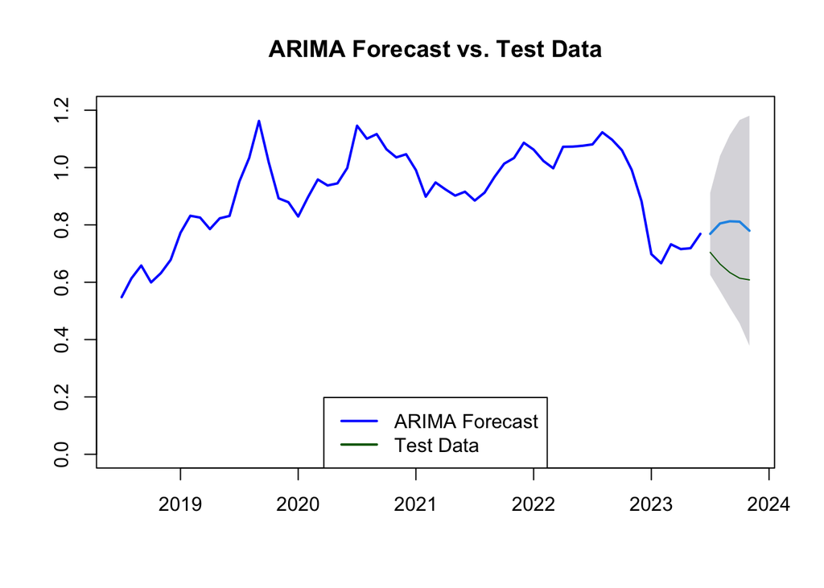

```r
# Plot ARIMA forecast and test data
plot(arima_future_pred_compare, col = "blue", lwd = 2, ylim = c(0, 1.2), main = "ARIMA Forecast vs. Test Data")
lines(test.ts1, col = "darkgreen")
legend("bottom", legend = c("ARIMA Forecast", "Test Data"), col = c("blue", "darkgreen"), lwd = 2)
```